# Part II - (Ford GoBike System Data Analysis)

## by (Ireyemi Stephen)

## Investigation Overview

In this investigation I looked other feautures of the dataset is related to bike-trip duration.The main focus on start_hourofday, start_dayofweek and duration_minutes.

## Dataset Overview

This data set includes information about individual rides made in a bike-sharing system covering the greater San Francisco Bay area. It contains 183412 observations with 16 associated variables. 10140 data points were removed from the analysis due to inconsistencies or missing information then my dataset structure became 173272 observations with 17 features.

## Distribution of Bike-trip Duration

This is the time taken(in minutes) to ride a bike by FordGo Bike user. Most bike-trips were less than 30 minutes. After a deeper investigation, it is observed that more than 96% of trips took less than 30 minutes and only 0.79% of trips are of duration more than 1hr.

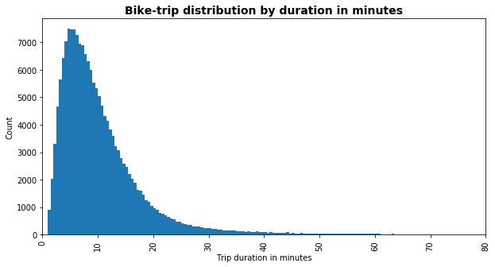

## Distribution of Start weekday?

Start weekday is the day the bikers begin their ride in the week. Most rides were done on Thursdays while the weekends(Saturday and Sunday has the least count of trips taken).

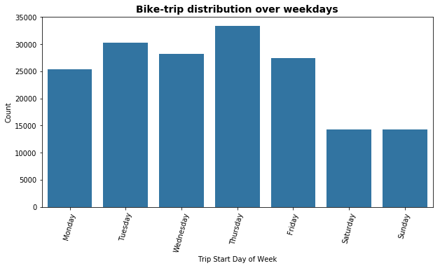

## Distribution of Start Hour of Day

This is the hour of the day in when users begin their ride. It has two highest peak times : 8am and 5pm. This should be due to the fact that people leave their homes and head back home at those peak hours.

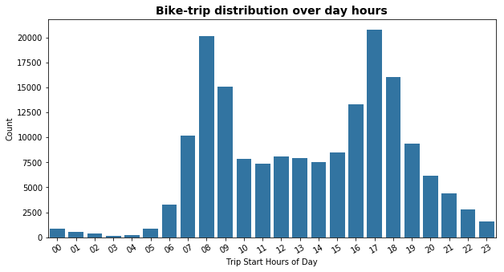

## Distribution of Bike user-type

```
Subscriber    90.487788
Customer       9.512212
Name: user_type, dtype: float64
```

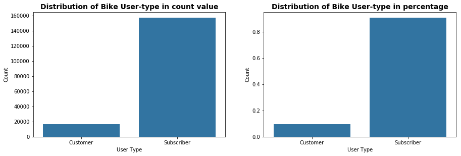

## User-type vs Bike-trip Duration

Despite that fact that we have more subscribers than customers, Customers have the longest bike-trip duration.

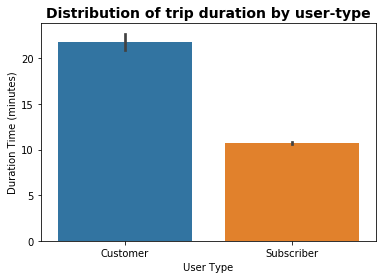

## User-type vs Start weekday

Using the count method, subscribers rode more bikes than customers for everyday in the week but as seen by the previous slide customers have longer duration of bike trips.

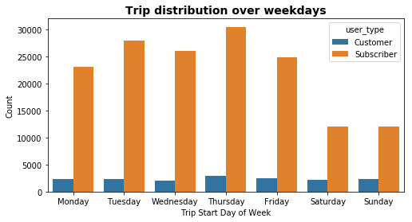

## User-type vs Start Hour of Day

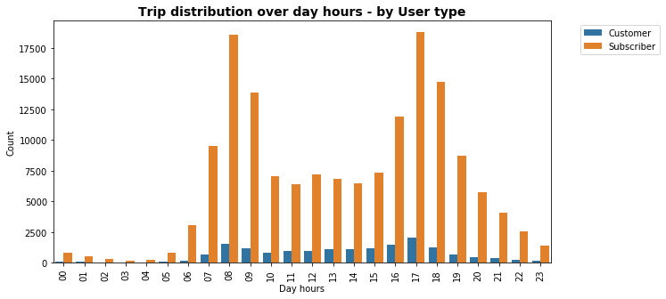

## What is the trip duration over day of week by user type?

This measures the average time (in minutes) users spend riding bikes during the week categorically. It is observed in this distribution that users spend more time riding bikes on weekend than weekdays. Bike-trips on weekends are almost 30minutes. During the working days, Monday has the highest duration of average bike use while Tuesdays have the least avergae bike time.

```
<function matplotlib.pyplot.show(*args, **kw)>
```

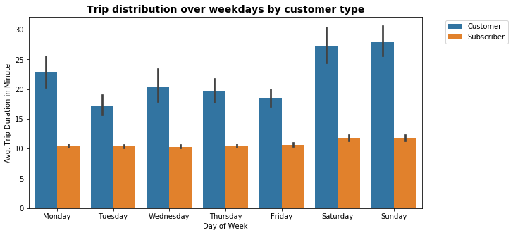

## What is the trip duration over hour of day by user type?

From observation, some customers ride bikes the longest at 3am which is really unusually.

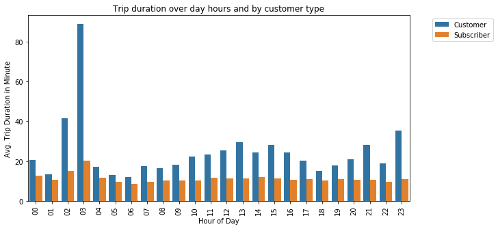

## What is the relationship between trip week day and hour of day by user type?

This shows a deep relationship between hour of day of trips, week day of trips and user type.

From the subscribers heatplot, highest number of subscribers are on Tuesday 8am and Thursday 8am & 5pm having an average of 4000 subscribers. It is obvious that subscribers use bikes everyday of the week at every hour of the day.

From the customers heatplot, Thursday 5pm has the highest bike usage. There are days when customers did not use bikes at some givens hours. This is obvious on Monday and Tuesday 3am and Wednesday 2am.

Comparing both heatplots; it is seen that at mid-hours of the day subscribers did not use bikes as the customers compared to their distribution respectively.

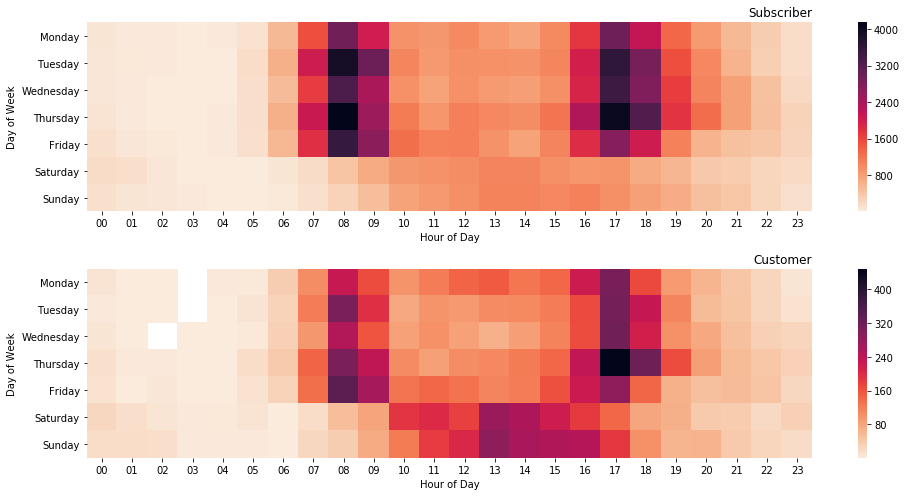